# R for Data Science

Set up a project, then play the *whole game*: load → tidy → transform → visualise

Postgraduate R Tutorial

2026-06-08

# Welcome

Today we do two things:

1. **Set up a project properly** — folders, paths, and the idea of *tidy data* — so your work is organised and reproducible from day one.
2. Then play the **whole game** of data science, following data in its natural direction: **load it in → tidy it → transform it → visualise it.**

## The data science cycle

> **Import → Tidy → Transform ⇄ Visualise → (Model → Communicate)** …all sitting inside **Program**.

We’ll follow it left to right today:

- **Set up** — a project structure that keeps everything findable and reproducible.
- **Import** — get a data file into R.
- **Tidy** — reshape it into a consistent form.
- **Transform** — filter, derive variables, summarise by group.
- **Visualise** — turn the table into a picture. *(We finish here.)*

# Part 1 · Set up your project

> Get organised *before* you analyse. Future-you will thank present-you.

## Always work in an RStudio Project

An **RStudio Project** (`.Rproj`) bundles everything for one piece of work.

- Open the project and your **working directory is the project folder** — automatically.
- No more `setwd("C:/Users/neil/Desktop/...")` that breaks on every other machine.
- Each project gets its own history, and you can have several open at once.

> Create one with **File → New Project → New Directory**. One project = one paper / thesis chapter / analysis.

## A sensible folder structure

```
my-analysis/
├── my-analysis.Rproj      # the project file — open THIS
├── README.md              # what is this, who, how to run it
├── data-raw/              # original data — READ-ONLY, never edit by hand
├── data/                  # cleaned / derived data you generate from data-raw
├── Code/                  # your analysis scripts (.R) or Quarto docs (.qmd)
├── output/
│   ├── figures/           # plots you export
│   └── tables/            # results tables
└── renv/                  # optional: a reproducible package library
```

Two principles: **raw data is sacred and read-only**; **everything in `output/` is regenerable** by re-running your scripts.

## Paths that don’t break

```r
# Bad — absolute, machine-specific:
read_csv("C:/Users/neil/Desktop/project/data-raw/palmerpenguins.csv")

# Good — relative to the project root:
read_csv("data-raw/palmerpenguins.csv")

# Robust — builds the path correctly on any OS / machine:
library(here)
read_csv(here("data-raw", "palmerpenguins.csv"))
```

Because you’re in a Project, relative paths just work. `here::here()` makes them bullet-proof even from sub-folders.

## Reproducible habits

- Write your analysis in a **script** (`.R`) or **Quarto** (`.qmd`) — not the console — so it’s saved and re-runnable.
- Run a line / selection with **Cmd/Ctrl + Enter**; run the whole file with **Cmd/Ctrl + Shift + Enter**.
- **Restart R often** (Session → Restart R) and re-run from the top.

> Turn off “save workspace to .RData”: **Tools → Global Options → uncheck “Restore .RData”**. A script that only works because of leftover objects isn’t reproducible.

# Part 2 · R foundations

> The minimum syntax you need before touching data.

## Assignment & naming

```r
# Assign with <-   (shortcut: Alt/Option + -)
mean_mass <- 4200

# Names: lowercase, words separated by _ (snake_case)
flipper_summary <- 1   # good
FlipperSummary  <- 1   # avoid
flipper.summary <- 1   # avoid
```

- Use `<-` to assign; reserve `=` for arguments inside functions.
- Nothing prints when you assign — type the object’s name to see it.

## Calling functions

```r
seq(from = 1, to = 10, by = 2)
```

```
#> [1] 1 3 5 7 9
```

- Functions take **arguments** as `name = value`.
- First arguments are usually passed by position; name the rest for clarity.
- `?seq` opens the help page; Tab-completion shows argument names.

## Code style

```r
# Spaces around operators and after commas:
mean(x, na.rm = TRUE)      # good
mean(x,na.rm=TRUE)         # cramped

# One statement per line; descriptive snake_case names:
mean_body_mass <- mean(penguins$body_mass_g, na.rm = TRUE)
```

- Spaces around `<-`, `==`, `+`, `*`; a space after every comma.
- The **{styler}** package reformats code automatically; **{lintr}** flags problems.

> Code is read far more often than written — including by you, in six months.

# Part 3 · Tidy data

> The shape we’re aiming for. Get here and everything downstream is easy.

## The three rules of tidy data

1. Each **variable** is a column.
2. Each **observation** is a row.
3. Each **value** is a cell.

For us: **one row per specimen**, one column per measured trait, with `species`, `site`, and `sex` as their own columns.

# The whole game

> **Import → Tidy → Transform → Visualise.** Now we run real data through it.

## Import: `read_csv()`

```r
library(tidyverse)

penguins <- read_csv("data-raw/palmerpenguins.csv")
```

`readr::read_csv()` gives you:

- a **tibble** (a tidy-friendly data frame),
- automatic **column-type guessing**, printed so you can check it,
- handy arguments: `na = c("", "NA", "-999")`, `skip =`, `col_types =` to override guesses.

> Always eyeball the type report and first rows — silent mis-typing is the #1 import bug.

## Other importers

| Format | Function | Package |
| --- | --- | --- |
| `.csv` / delimited | `read_csv()`, `read_delim()` | readr |
| Excel `.xlsx` | `read_excel()` | readxl |
| `.rds` (one R object) | `read_rds()` | readr |
| SPSS / Stata / SAS | `read_sav()`, `read_dta()` | haven |

## Meet the data

We’ll use **morphometric data** — measurements across species and sites. Once loaded:

```r
penguins
```

```
#> # A tibble: 344 × 8
#>   species island    bill_length_mm bill_depth_mm flipper_length_mm body_mass_g
#>   <fct>   <fct>              <dbl>         <dbl>             <int>       <int>
#> 1 Adelie  Torgersen           39.1          18.7               181        3750
#> 2 Adelie  Torgersen           39.5          17.4               186        3800
#> 3 Adelie  Torgersen           40.3          18                 195        3250
#> 4 Adelie  Torgersen           NA            NA                  NA          NA
#> 5 Adelie  Torgersen           36.7          19.3               193        3450
#> 6 Adelie  Torgersen           39.3          20.6               190        3650
#> # ℹ 338 more rows
#> # ℹ 2 more variables: sex <fct>, year <int>
```

## A first look

```r
glimpse(penguins)
```

```
#> Rows: 344
#> Columns: 8
#> $ species           <fct> Adelie, Adelie, Adelie, Adelie, Adelie, Adelie, Adel…
#> $ island            <fct> Torgersen, Torgersen, Torgersen, Torgersen, Torgerse…
#> $ bill_length_mm    <dbl> 39.1, 39.5, 40.3, NA, 36.7, 39.3, 38.9, 39.2, 34.1, …
#> $ bill_depth_mm     <dbl> 18.7, 17.4, 18.0, NA, 19.3, 20.6, 17.8, 19.6, 18.1, …
#> $ flipper_length_mm <int> 181, 186, 195, NA, 193, 190, 181, 195, 193, 190, 186…
#> $ body_mass_g       <int> 3750, 3800, 3250, NA, 3450, 3650, 3625, 4675, 3475, …
#> $ sex               <fct> male, female, female, NA, female, male, female, male…
#> $ year              <int> 2007, 2007, 2007, 2007, 2007, 2007, 2007, 2007, 2007…
```

`glimpse()` is your first move on any new dataset: every column, its type, and a peek at the values.

## Tidy in practice: a messy table

Field data often arrives **wide** — species as column headers:

```r
counts_wide <- tribble(
  ~site,   ~Adelie, ~Gentoo, ~Chinstrap,
  "North",      12,      30,          5,
  "South",      18,      22,          9
)
counts_wide
```

```
#> # A tibble: 2 × 4
#>   site  Adelie Gentoo Chinstrap
#>   <chr>  <dbl>  <dbl>     <dbl>
#> 1 North     12     30         5
#> 2 South     18     22         9
```

`species` is a *variable* trapped in the *headers* — not tidy.

## `pivot_longer()` to the rescue

```r
counts_long <- counts_wide |>
  pivot_longer(
    cols      = -site,
    names_to  = "species",
    values_to = "count"
  )
counts_long
```

```
#> # A tibble: 6 × 3
#>   site  species   count
#>   <chr> <chr>     <dbl>
#> 1 North Adelie       12
#> 2 North Gentoo       30
#> 3 North Chinstrap     5
#> 4 South Adelie       18
#> 5 South Gentoo       22
#> 6 South Chinstrap     9
```

Now `species` and `count` are proper columns — ready to group, plot, model. (`pivot_wider()` does the reverse.)

## Transform: the pipe `|>`

The pipe passes the result on the left into the first argument on the right.

```r
# Nested (hard to read):
summarise(group_by(filter(penguins, !is.na(sex)), species), n = n())

# Piped (read top to bottom):
penguins |>
  filter(!is.na(sex)) |>
  group_by(species) |>
  summarise(n = n())
```

> Read `|>` as **“and then”** — it turns nested calls into a readable recipe.

## `filter()` — keep rows

```r
penguins |>
  filter(species == "Adelie", body_mass_g > 4000)
```

```
#> # A tibble: 35 × 8
#>   species island    bill_length_mm bill_depth_mm flipper_length_mm body_mass_g
#>   <fct>   <fct>              <dbl>         <dbl>             <int>       <int>
#> 1 Adelie  Torgersen           39.2          19.6               195        4675
#> 2 Adelie  Torgersen           42            20.2               190        4250
#> 3 Adelie  Torgersen           34.6          21.1               198        4400
#> 4 Adelie  Torgersen           42.5          20.7               197        4500
#> 5 Adelie  Torgersen           46            21.5               194        4200
#> 6 Adelie  Dream               39.2          21.1               196        4150
#> # ℹ 29 more rows
#> # ℹ 2 more variables: sex <fct>, year <int>
```

Operators: `== != < > <= >= & | %in%`, plus `is.na()`.

## `arrange()` & `select()`

**Reorder rows**

```r
penguins |>
  arrange(desc(body_mass_g)) |>
  select(species, body_mass_g)
```

```
#> # A tibble: 344 × 2
#>   species body_mass_g
#>   <fct>         <int>
#> 1 Gentoo         6300
#> 2 Gentoo         6050
#> 3 Gentoo         6000
#> 4 Gentoo         6000
#> 5 Gentoo         5950
#> 6 Gentoo         5950
#> # ℹ 338 more rows
```

**Pick columns**

```r
penguins |>
  select(species, island, sex)
```

```
#> # A tibble: 344 × 3
#>   species island    sex
#>   <fct>   <fct>     <fct>
#> 1 Adelie  Torgersen male
#> 2 Adelie  Torgersen female
#> 3 Adelie  Torgersen female
#> 4 Adelie  Torgersen <NA>
#> 5 Adelie  Torgersen female
#> 6 Adelie  Torgersen male
#> # ℹ 338 more rows
```

## `mutate()` — create variables

```r
penguins |>
  mutate(
    mass_kg    = body_mass_g / 1000,
    bill_ratio = bill_length_mm / bill_depth_mm
  ) |>
  select(species, mass_kg, bill_ratio)
```

```
#> # A tibble: 344 × 3
#>   species mass_kg bill_ratio
#>   <fct>     <dbl>      <dbl>
#> 1 Adelie     3.75       2.09
#> 2 Adelie     3.8        2.27
#> 3 Adelie     3.25       2.24
#> 4 Adelie    NA         NA
#> 5 Adelie     3.45       1.90
#> 6 Adelie     3.65       1.91
#> # ℹ 338 more rows
```

Where derived morphometrics live — ratios, indices, log-transforms for allometry.

## `group_by()` + `summarise()`

The workhorse for “compute something per species / site / treatment”:

```r
penguins |>
  group_by(species, sex) |>
  summarise(
    n         = n(),
    mean_mass = mean(body_mass_g, na.rm = TRUE),
    sd_mass   = sd(body_mass_g, na.rm = TRUE),
    .groups   = "drop"
  )
```

```
#> # A tibble: 8 × 5
#>   species   sex        n mean_mass sd_mass
#>   <fct>     <fct>  <int>     <dbl>   <dbl>
#> 1 Adelie    female    73     3369.    269.
#> 2 Adelie    male      73     4043.    347.
#> 3 Adelie    <NA>       6     3540     477.
#> 4 Chinstrap female    34     3527.    285.
#> 5 Chinstrap male      34     3939.    362.
#> 6 Gentoo    female    58     4680.    282.
#> # ℹ 2 more rows
```

# Visualise

> The payoff. We finish the game by turning data into pictures.

## The grammar of graphics

Every ggplot is built from the same pieces:

```r
ggplot(data = <DATA>) +
  geom_<TYPE>(mapping = aes(<MAPPINGS>))
```

- **data** — the data frame.
- **aes()** — *aesthetic mappings*: which variable maps to x, y, colour, shape…
- **geom_** — the geometric object representing the data (points, lines, bars…).
- Layers are added with **`+`**.

## A first plot

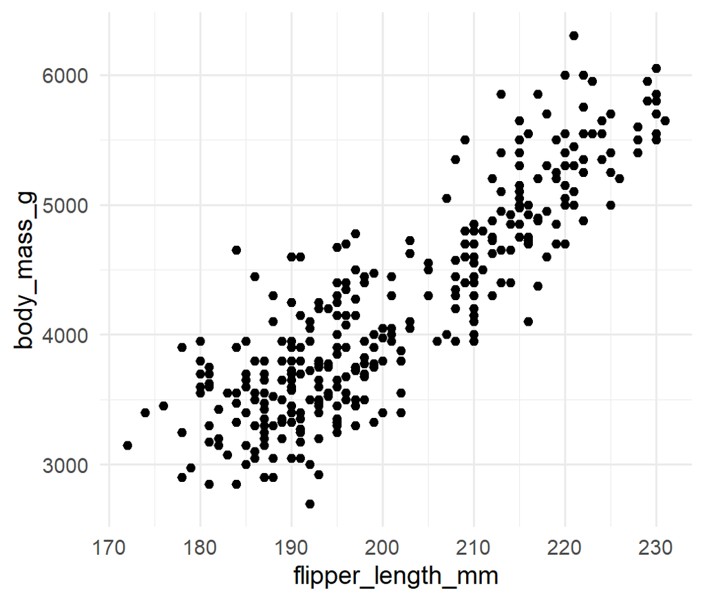

```r
ggplot(
  data = penguins,
  mapping = aes(x = flipper_length_mm,
                y = body_mass_g)
) +
  geom_point()
```

## Map a variable to colour

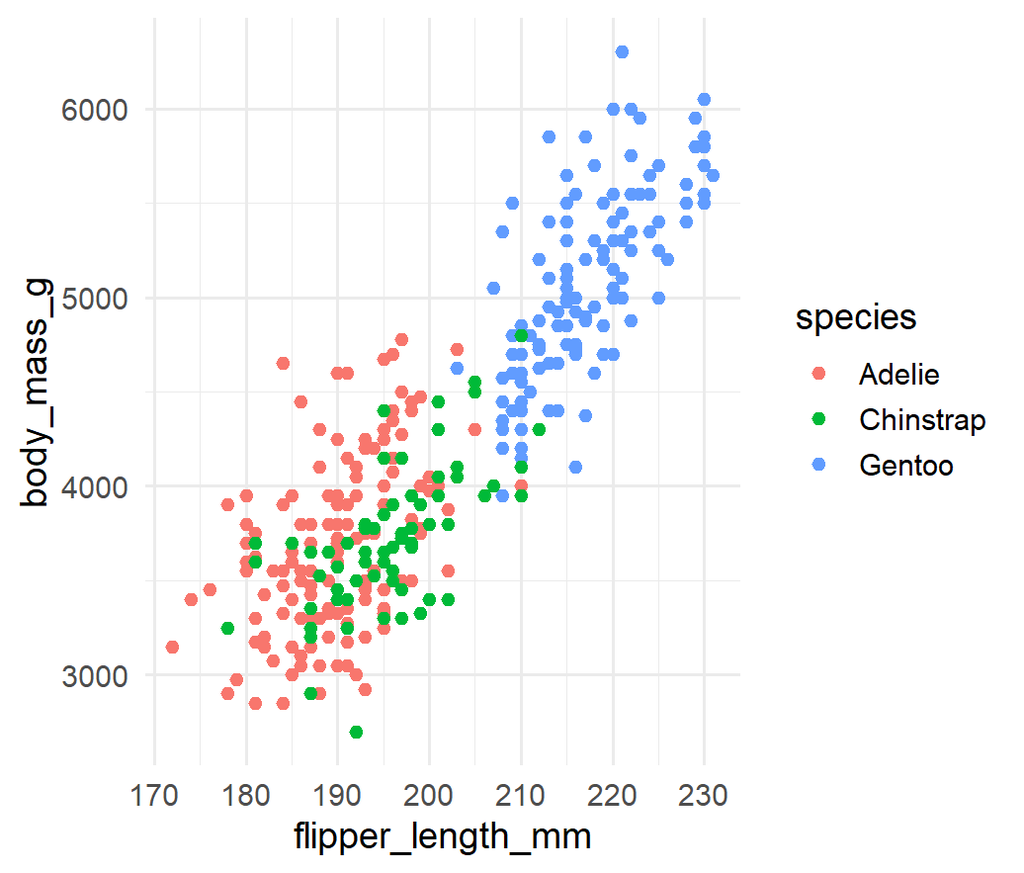

```r
ggplot(
  penguins,
  aes(x = flipper_length_mm,
      y = body_mass_g,
      colour = species)
) +
  geom_point()
```

Anything that should respond to the data goes **inside `aes()`**.

## Set vs. map

Want one fixed colour? **Set** it *outside* `aes()`:

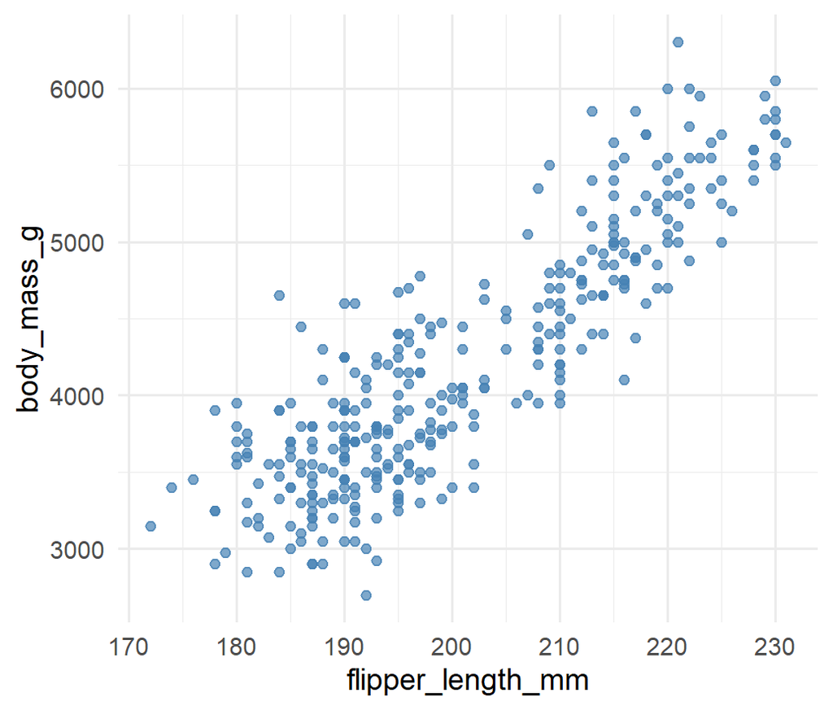

```r
ggplot(penguins, aes(flipper_length_mm, body_mass_g)) +
  geom_point(colour = "steelblue", alpha = 0.7)
```

> **Map** = a variable controls it (inside `aes()`). **Set** = fixed constant (outside `aes()`).

## Add a model layer

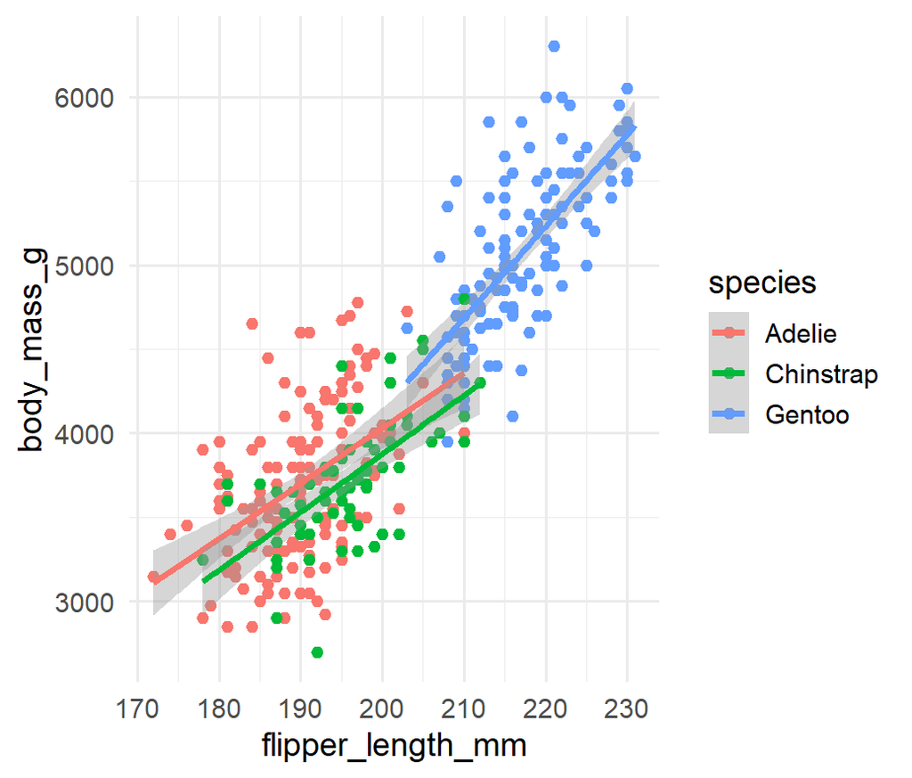

```r
ggplot(
  penguins,
  aes(x = flipper_length_mm,
      y = body_mass_g,
      colour = species)
) +
  geom_point() +
  geom_smooth(method = "lm")
```

One trend line **per group**, because `colour` is mapped globally.

## Facets — small multiples

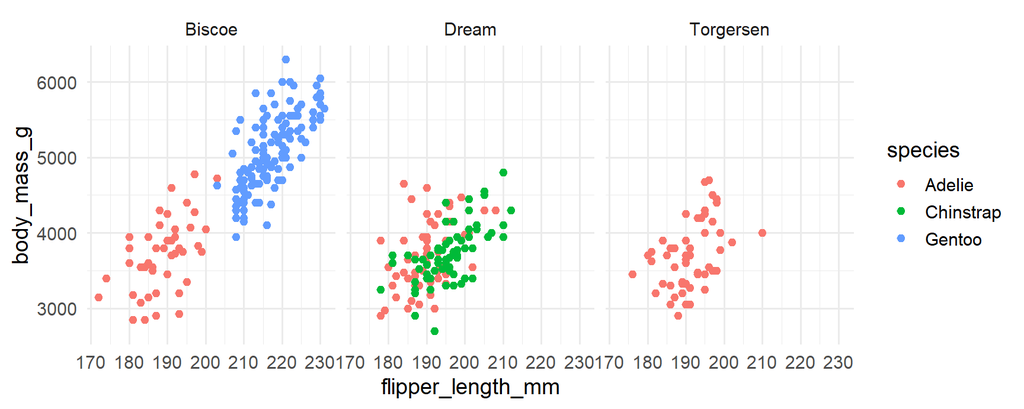

```r
ggplot(penguins, aes(flipper_length_mm, body_mass_g, colour = species)) +
  geom_point() +
  facet_wrap(~ island)
```

`facet_wrap(~ var)` splits one plot into a panel per level — ideal for sites / treatments.

## Putting it together

The whole game in one piped pipeline, ending in a plot:

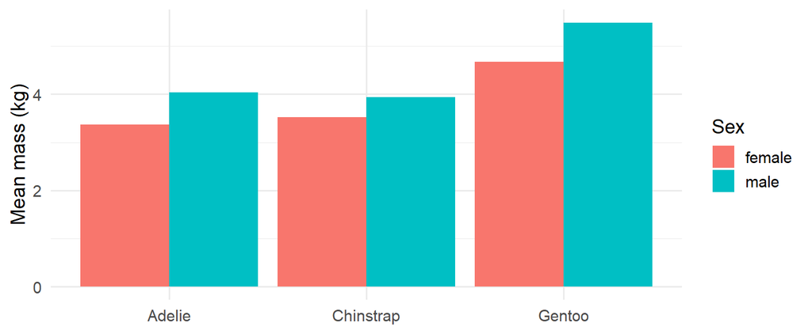

```r
penguins |>                                   # import (loaded earlier)
  filter(!is.na(body_mass_g), !is.na(sex)) |> # transform: drop missing
  mutate(mass_kg = body_mass_g / 1000) |>     # transform: derive variable
  group_by(species, sex) |>                   # transform: group
  summarise(mean_kg = mean(mass_kg), .groups = "drop") |>
  ggplot(aes(species, mean_kg, fill = sex)) + # visualise
  geom_col(position = "dodge") +
  labs(x = NULL, y = "Mean mass (kg)", fill = "Sex")
```

# Wrap up

## What we covered

**Set-up & foundations**

- RStudio Projects + folder structure
- Relative paths / `here()`
- Assignment, naming, functions, style
- Tidy data: the 3 rules

**The whole game**

- `read_csv()` and friends
- `pivot_longer()` → tidy
- dplyr: filter / arrange / select / mutate / summarise + `|>`
- ggplot2: aes, geoms, set vs map, facets

## Your turn — exercises

1. Make a project folder for a small analysis with `data-raw/`, `data/`, `R/`, and `output/figures/`.
2. Read **one of your own CSVs** with `read_csv()`, check the column types, and `glimpse()` it.
3. Compute the number of specimens and mean body mass **per island** (`group_by` + `summarise`).
4. Plot `bill_length_mm` vs `bill_depth_mm`, colour by `species`, add `geom_smooth(method = "lm")`. Then facet by species — what changes? *(Simpson’s paradox!)*

Bonus: take a wide spreadsheet from your own work and tidy it with `pivot_longer()`.

## Getting unstuck

- **`?function`** — the help page (the Examples section is gold).
- **`vignette("dplyr")`** — narrative, worked guides for a package.
- Google the **exact error message**; Posit Community & Stack Overflow `[r]` `[tidyverse]`.
- Make a **reprex** with the **{reprex}** package before asking — you’ll often solve it yourself.

## Where to go next

- 📖 **R for Data Science (2e)** — free: r4ds.hadley.nz
- 🧾 **Posit cheatsheets** — ggplot2, dplyr, tidyr: posit.co/resources/cheatsheets
- 🐞 For ecology, pair these with `{vegan}`, `{lme4}`/`{glmmTMB}`, `{DHARMa}`

> The whole game is just this loop, run over and over: **import → tidy → transform ⇄ visualise.** Everything else is depth.

## Thank you

Questions?

Slides built with Quarto + reveal.js. Source: `whole-game.qmd`. Content adapted from *R for Data Science (2e)* (CC BY-NC-ND).